# Applied Linear Statistical Models

01 - Introduction to R and RStudio

[Mario Banuelos](http://www.mbgmath.com)

## What is R?

R is a free, open-source software and programming language developed in 1995 at the University of Auckland as an environment for statistical computing and graphics [(Ikaha and Gentleman, 1996)](https://www.stat.auckland.ac.nz/~ihaka/downloads/R-paper.pdf) . Since then, R has become a popular software environment for data analysis in a variety of disciplines.

### Why Should I Learn R?

- It is free and it is a widely used statistical programming language!
- Reproducible Research
- [Community Resources](https://cran.r-project.org/web/views/)
- Learning Resources
  - ISLR Textbook
  - [RStudio Cheat Sheets](https://rstudio.com/resources/cheatsheets/)
  - [R Basics](https://www.udemy.com/course/r-basics/)
  - [ggplot2](https://ggplot2.tidyverse.org/index.html)

## RStudio

RStudio has 4 main window panes that allows for

- *Script / Editing Pane*
  - This area allows you to write scripts or entire R Notebooks
- *Console*
  - This interactive area executes code (line-by-line) as you type it
- *File Navigator / Plot Viewer / Help Pane*
  - Shows your current working folder and displays plots + help
- *Environment Pane*
  - Shows any global variables that you can access / manipulate

### R - Console

We will write some code to execute in the R Console, covering:

- Simple Arithmetic
- Variables and Variable Assignment
- Functions, Plotting, and Help
- Indexing and the Global Environment

**Practice:** Use `R` (in the console) to complete the following:

1. Create a variable `x` and variable `y` and add them together. Save the result to a new variable `z`
2. Create a *summary graph* of your GPA vs # of Units you have taken as a student.

### R Scripts

Let’s combine all we covered into a script (so that we can run it later). We can choose to run scripts:

- line by line
- in sections
- entirely

## R Markdown Notebooks

Note: comments start with a #. It’s a great idea to comment your # code.

```r
# simple R code chunk
x <- 2
y <- 5
x + y
```

```
[1] 7
```

```r
# Load necessary libraries
# most of the data we will use exists inside these 2 libraries
library('alr4')
library('ISLR')
library('ggplot2')

# store myheight (mother-daugher height data) as a global variable
myH <- Heights

# Note: for the UN problem on the homework, the data file is UN11

# Summary Statistics
# var() calculates the variance
# $ accesses variables/columns of data
var(myH$dheight)
```

```
[1] 6.760274
```

```r
# mean() calculates the mean
mean(myH$mheight)
```

```
[1] 62.4528
```

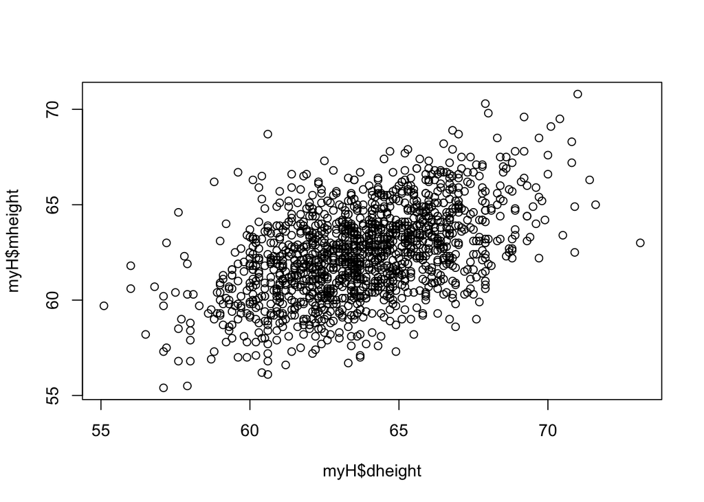

```r
# creating a summary graph (predictor vs response)
plot(myH$dheight, myH$mheight)
```

Now, let’s shift our attention to `fuel2001` data.

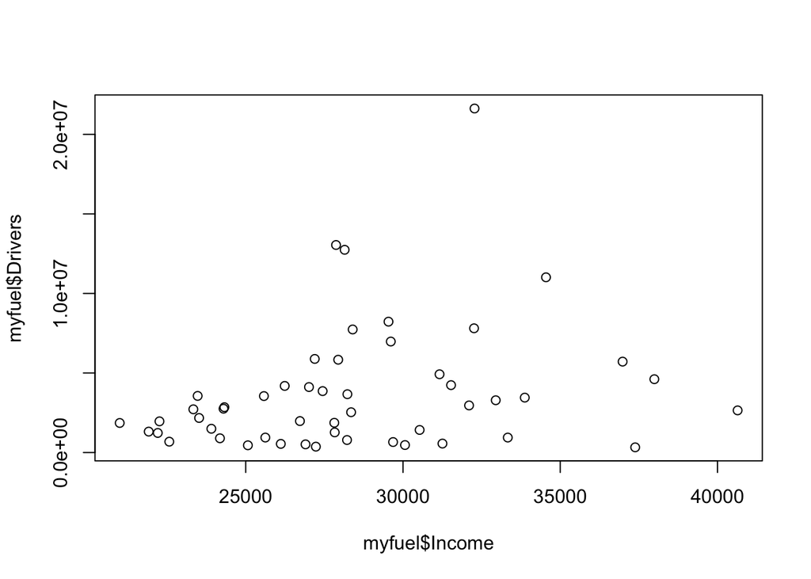

```r
# save myfuel as global variable
myfuel <- fuel2001

# Plotting predictor vs response
# Size
plot(myfuel$Income, myfuel$Drivers) # default plot
```

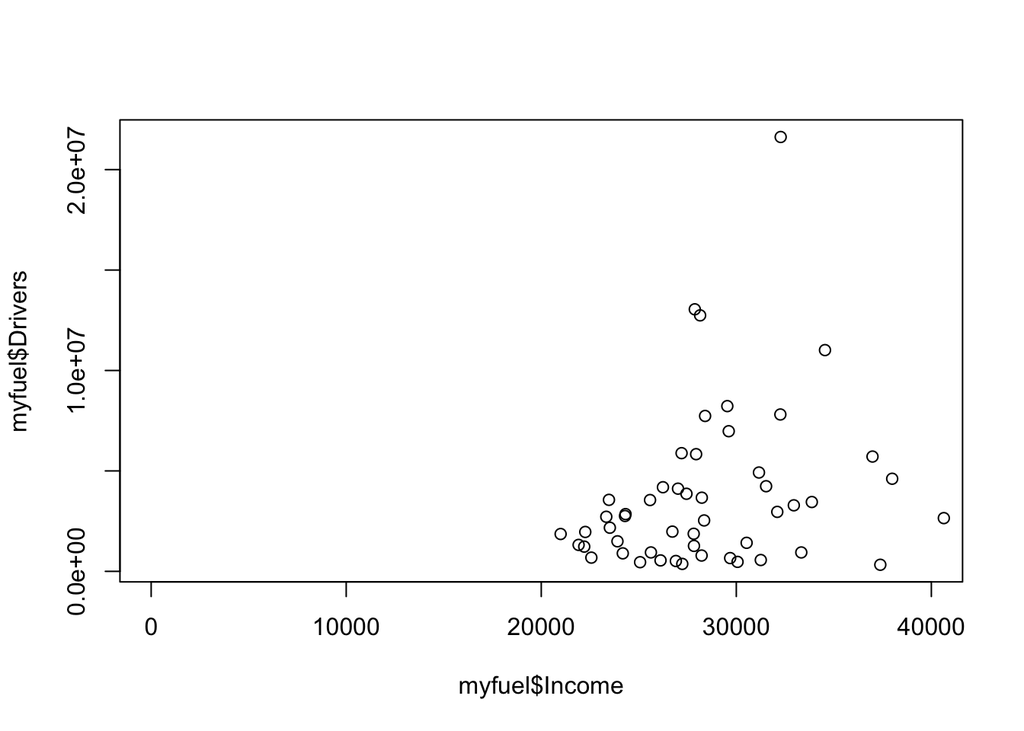

```r
plot(myfuel$Income, myfuel$Drivers, xlim=c(0,40000))
```

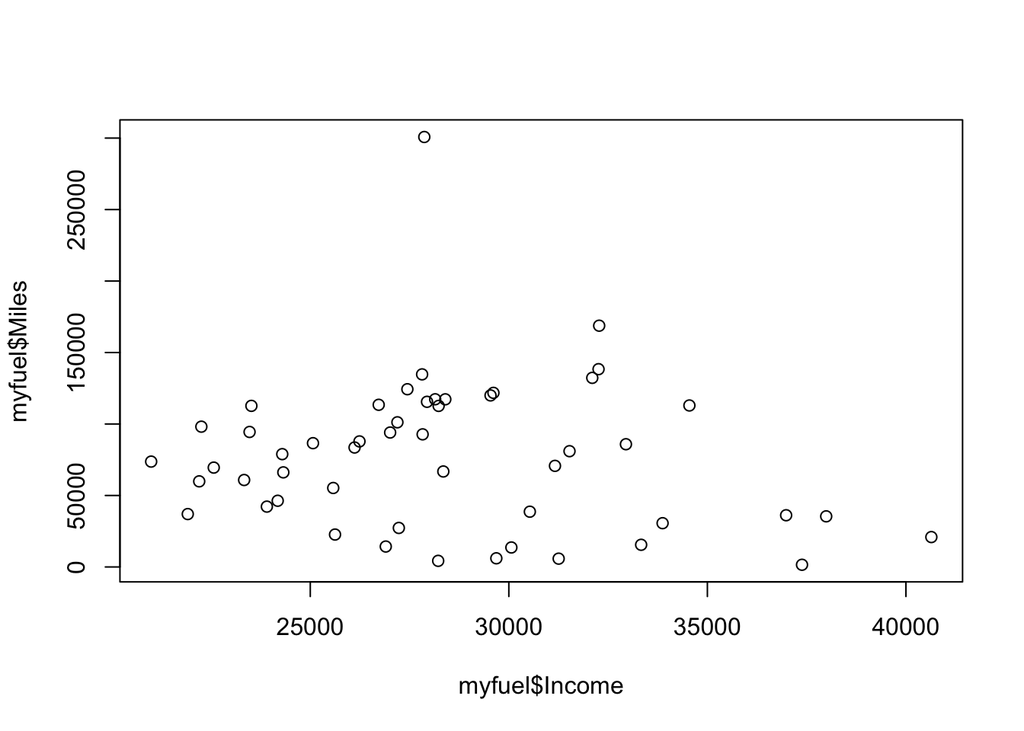

```r
# Transformations
plot(myfuel$Income, myfuel$Miles )
```

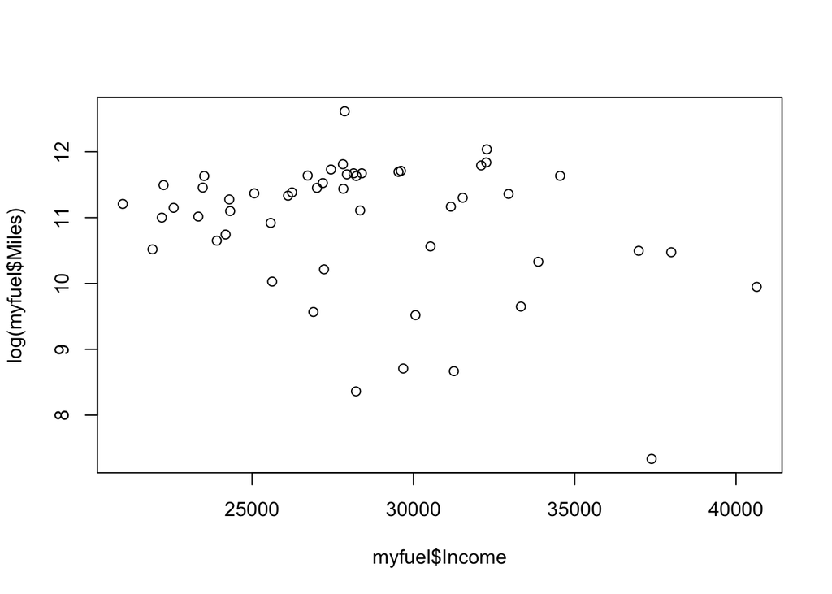

```r
plot(myfuel$Income, log(myfuel$Miles) )
```

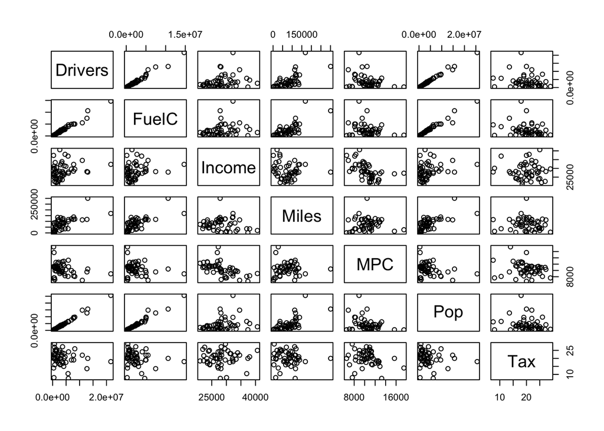

```r
# Scatterplot Matrices
plot(myfuel)
```

```r
# Adding new variables (based on the predictors)
# to the data. These are called regressors.
myfuel$FuelPerP <- 1000 * myfuel$FuelC / myfuel$Pop

# Note: we will not be using FuelC or Pop to predict/model Fuel

# --- Here is a good place to stop by Monday

# One of the most powerful functions
?which
```

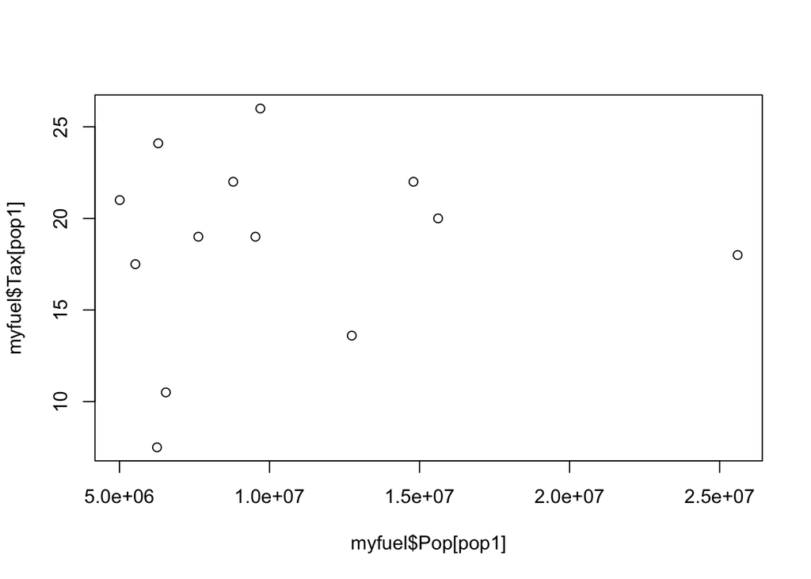

```r
# Find all (pop1 stores these indices)
pop1 <- which(myfuel$Pop > 5000000)
# Note:  million could also be written as 5e6

# plot
plot(myfuel$Pop[pop1], myfuel$Tax[pop1])
```

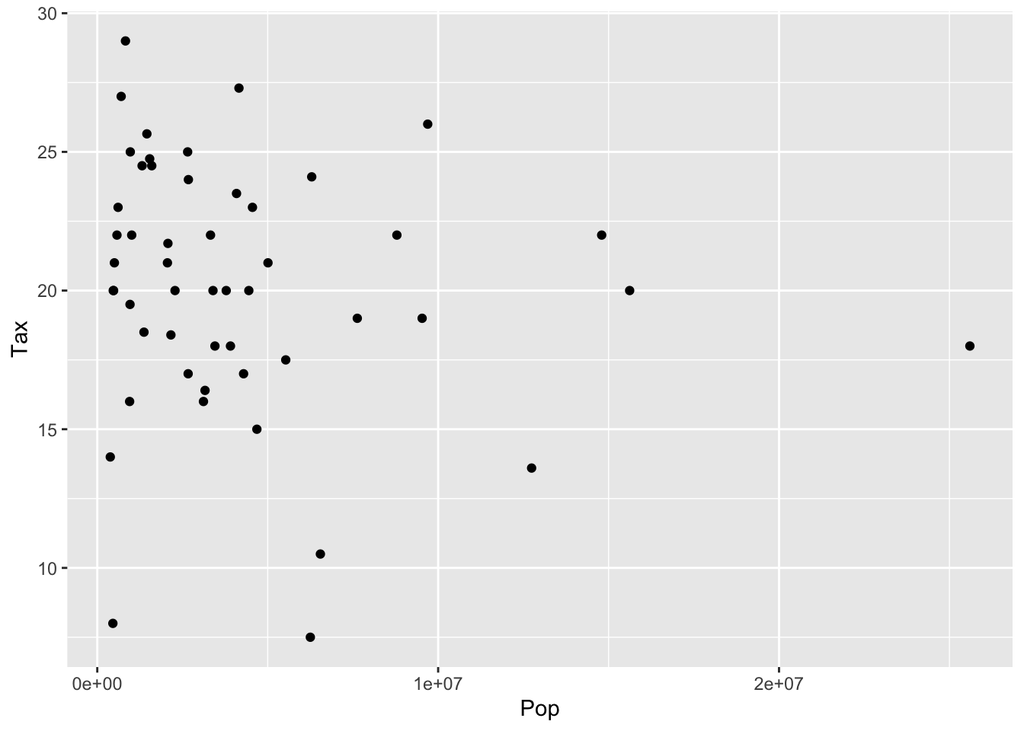

```r
# more advanced plotting
ggplot(data = myfuel,
       aes(x = Pop, y = Tax, label=rownames(myfuel))) +
  geom_point() #+
```

```r
 #geom_text() +
 #ylim(c(20, 30))
```